# Ejercicio 2

Josue Ivan Murillo Alba

```r
library(dplyr)
```

Para esta pr´actica, utiliza los datos de la tabla wage1. Considera los mismos datos que en la primera parte, con Yi = wagei , Xi = educi . (1) Como se intertpreta el parametro estimado α.

Este valor representa la intersección de la función de regresión muestral FRM hacia el eje de las ordenadas, en este caso la intersección es negativa (-0.9) el cual el eje representa el salario en este caso un salario negativo no tiene ningun signicado real

2. Como se intertpreta el parametro estimado βˆ.

Este coeficiente representa la pendiente de la función, es decir que cada que se aumenta un año de ecolaridad el salario incrementa en proporción (0.54)

3. De acuerdo a este modelo lineal, ¿cuanto predice que sera el sueldo (wage), en promedio, para una persona con 10 años de educacion?

```r
tabla<-read.csv("wage1.csv")

tabla<-select(tabla, wage, educ)

tabla1<-rename(tabla, Y=wage, X=educ)
 x.<-(tabla1$X-mean(tabla1$X))
 y.<-(tabla1$Y-mean(tabla1$Y))


B<-sum((x.)*(y.))/sum((x.)^(2))
B
```

```
## [1] 0.5413593
```

```r
a<-mean(tabla1$Y)-B*mean(tabla1$X)
a
```

```
## [1] -0.9048516
```

```r
y_gorro<-a+tabla1$X*B
head(y_gorro)
```

```
## [1] 5.050100 5.591459 5.050100 3.426022 5.591459 7.756896
```

```r
u<-tabla1$Y-y_gorro
```

```r
W_10<-a+B*10
W_10
```

```
## [1] 4.508741
```

4. De acuerdo a este modelo lineal, ¿cu´anto predice que sera el sueldo (wage), en promedio, para una persona con 16 a˜nos de educacion?

```r
W_16<-a+B*16
W_16
```

```
## [1] 7.756896
```

5. De acuerdo a este modelo lineal, ¿cuanto predice que aumentara el sueldo (wage), en promedio, si una persona aumenta 1 a˜no de educacion?

aumenta en proporcion al estimador de la pendiente “B” es decir 0.5413593

6. De acuerdo a este modelo lineal, ¿cu´anto predice que aumentara el sueldo (wage) si una persona aumenta 4 a˜nos de educacion?

```r
W_mas4<-B*4
W_mas4
```

```
## [1] 2.165437
```

7. Calcula

```r
sum((y.)^2)
```

```
## [1] 7160.414
```

8. Calcula

```r
sum((y_gorro)^2)
```

```
## [1] 19465.61
```

9. Calcula

```r
sum_u2<-sum(u^2)
```

[output not shown]

10. Realiza un diagrama de dispersion ˆui vs Xi, con ˆui en el eje vertical.

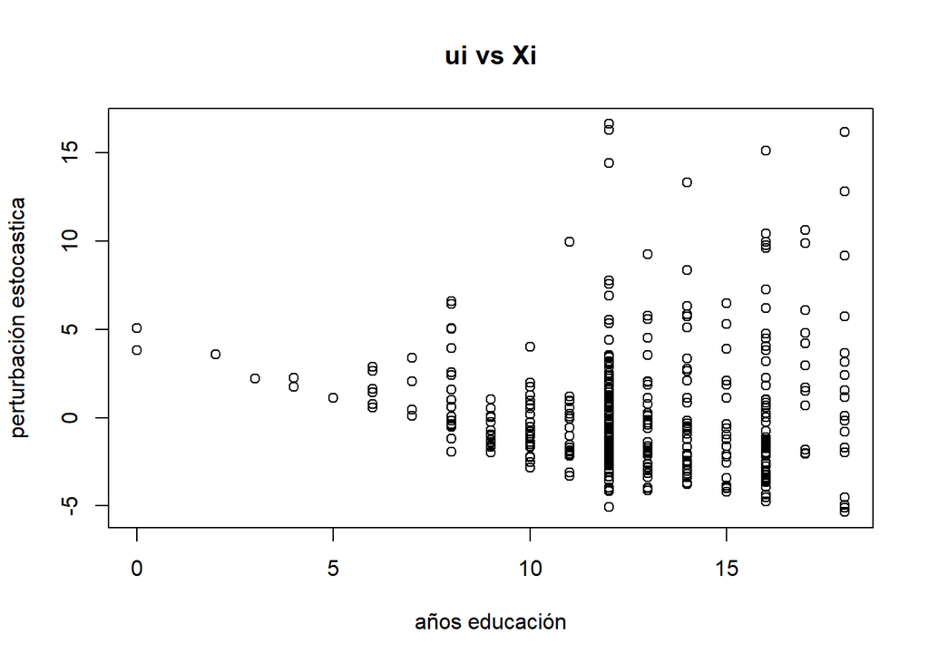

```r
plot(tabla1$X, u,
     xlab = "años educación",
     ylab = "perturbación estocastica",
     main = "ui vs Xi")
```

11. Calcula σˆ2

```r
n<-length(tabla1$X)

varianza<-(sum_u2/n-2)
varianza
```

```
## [1] 9.370118
```

12. Calcula var(βˆ)

```r
sum_x2<-sum((x.)^2)
var_B<-varianza/sum_x2
var_B
```

```
## [1] 0.002327731
```

13. Calcula el error est´andar e.e.(βˆ)

```r
eeB<-(var_B)^(0.5)
eeB
```

```
## [1] 0.04824657
```

14. Calcula var(ˆα)

```r
sum_X<-sum(tabla1$X)
sum_X2<-sum((tabla1$X)^2)

var_a<-(sum_X2*varianza)/(n*sum_x2)
var_a
```

```
## [1] 0.385182
```

15. Calcula e.e(ˆα)

```r
eea<-(var_a)^(0.5)
eea
```

```
## [1] 0.6206303
```

16. La covarianza entre βˆ y ˆα est´a dada por cov(ˆα, βˆ) = −Xvar ¯ (βˆ). Calcula cov(ˆα, βˆ).

```r
cov_ab<-(-mean(tabla1$X))*var_B
cov_ab
```

```
## [1] -0.02924268
```

17. Compara el error estandar calculado, con las estimaciones dadas por R en el resumen (summary) de estimadores del modelo lineal

```r
modelo <- lm(Y ~ X, data = tabla1)
resumen <- summary(modelo)
resumen
```

```
##
## Call:
## lm(formula = Y ~ X, data = tabla1)
##
## Residuals:
##     Min      1Q  Median      3Q     Max
## -5.3396 -2.1501 -0.9674  1.1921 16.6085
##
## Coefficients:
##             Estimate Std. Error t value Pr(>|t|)
## (Intercept) -0.90485    0.68497  -1.321    0.187
## X            0.54136    0.05325  10.167   <2e-16 ***
## ---
## Signif. codes:  0 '***' 0.001 '**' 0.01 '*' 0.05 '.' 0.1 ' ' 1
##
## Residual standard error: 3.378 on 524 degrees of freedom
## Multiple R-squared:  0.1648, Adjusted R-squared:  0.1632
## F-statistic: 103.4 on 1 and 524 DF,  p-value: < 2.2e-16
```

diferencia

```r
dif_eeX<-0.05325-0.04824657
dif_eeX
```

```
## [1] 0.00500343
```

```r
dif_eeY<-0.68497-0.6206303
dif_eeY
```

```
## [1] 0.0643397
```